# HT7

2023-04-21

## Paquetes de RStudio

```
## dummy 0.1.3
```

```
## dummyNews()
```

## 1 - Use los mismos conjuntos de entrenamiento y prueba de las hojas de trabajo pasadas para probar el algoritmo.

## 2 - Explore los datos y explique las transformaciones que debe hacerle para generar un modelo de máquinas vectoriales de soporte.

### Se llevara a cabo un analisis exploratorio

=> Encontrando todos los NA de la clean data

```r
sum(is.na(clean_data))
```

```
## [1] 43
```

```r
colSums(is.na(clean_data))
```

```
##       neighborhood         houseStyle          houseZone     houseUtilities
##                  0                 33                 10                  0
##         roadAccess        remodelated          roofStyle       roofMaterial
##                  0                  0                  0                  0
##     overallQuality   overallCondition  exteriorCondition foundationMaterial
##                  0                  0                  0                  0
##           basement  basementCondition          fireplace         garageArea
##                  0                  0                  0                  0
##               pool  additionalFeature         livingArea          yearBuilt
##                  0                  0                  0                  0
##          salePrice           saleType           mSZoning
##                  0                  0                  0
```

Se puede observar que se presentan datos vacios en “houseStyle” y en “houseZone”. Por si se llevara a cabo un modelo de maquuinas vectoriales necesitaremos tener cuidado con estos datos.

=> Tendencias de la data

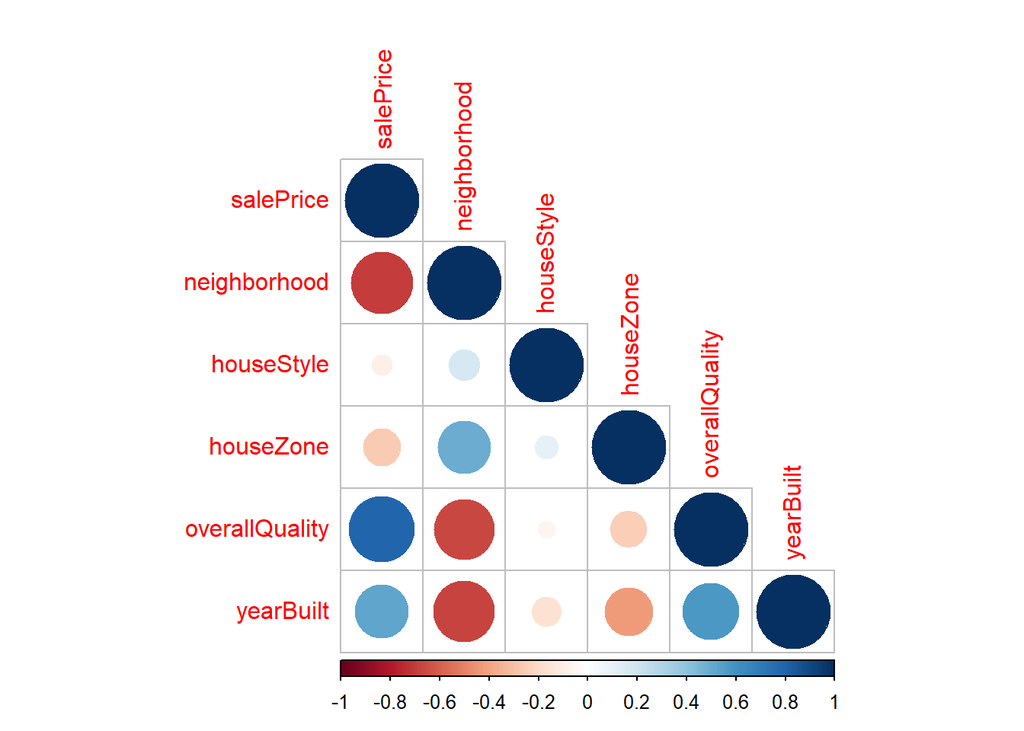

```r
correlations <- cor(clean_data[,c("salePrice", "neighborhood", "houseStyle", "houseZone", "overallQuality", "yearBuilt")], use="pairwise.complete.obs")
corrplot(correlations, method="circle", type="lower", sig.level = 0.01, insig = "blank")
```

Se puede observar que el año donde se realizo la casa, su precio y la calidad de esta misma esta correlacionado con el vecindario, estos tres datos tienen una correlacion negativa, esto nos indica que las condiciones actuales puenden reducir a lo largo de los años.

## 3 - Use como variable respuesta la variable categórica que especifica si la casa es barata, media o cara

```r
clean_data$economy <- ifelse(clean_data$salePrice < 163000, "Economic", ifelse(clean_data$salePrice >= 163000 & clean_data$salePrice <= 214000, "Average", "Expensive"))
```

```r
set.seed(5)
expected_result <- clean_data$salePrice
partition <- createDataPartition(y=expected_result, p=.75, list=F)
train_set <- clean_data[partition,]
test_set <- clean_data[-partition,]
```

## 4 - Genere varios (más de 2) modelos de SVM con diferentes kernels y distintos valores en los parámetros c, gamma (circular) y d (en caso de que utilice el polinomial). Puede tunear el modelo de forma automática siempre que explique los resultados.

### –> Preparar los modelos con diferentes kernels

```r
train_set <- na.omit(train_set)
test_set <- na.omit(test_set)

train_set$economy <- as.factor(train_set$economy)
test_set$economy <- as.factor(test_set$economy)

modelSVM_L01<-svm(economy~., data=train_set, cost=2^10, kernel="linear")
modelSVM_L02<-svm(economy~., data=train_set, cost=2^-10, kernel="linear")
modelSVM_L03<-svm(economy~., data=train_set, cost=0.5, kernel="linear")
modelSVM_R01<-svm(economy~., data=train_set, gamma=2^-10, kernel="radial")
modelSVM_R02<-svm(economy~., data=train_set, gamma=2, kernel="radial")

# Tuneando modelos para obtener diferentes resultados
modelTunedL <- tune.svm(economy~., data=train_set, cost=c(0.01,0.1,0.5,1,5,10,16,20,32), kernel="linear")
modelTunedP <- tune.svm(economy~., data=train_set, cost=c(0.01,0.1,0.5,1,5,10,16,20,32), kernel="polynomial", degree = c(2,3))
```

## 5 - Use los modelos para predecir el valor de la variable respuesta

```r
predictionL01<-predict(modelSVM_L01, newdata=test_set)
predictionL02<-predict(modelSVM_L02, newdata=test_set)
predictionL03<-predict(modelSVM_L03, newdata=test_set)
predictionR01<-predict(modelSVM_R01, newdata=test_set)
predictionR02<-predict(modelSVM_R02, newdata=test_set)
predictionTuned01 <- predict(modelTunedL$best.model, newdata=test_set)
predictionTuned02 <- predict(modelTunedP$best.model, newdata=test_set)
```

## 6 - Haga las matrices de confusión respectivas

Modelo modelSVM_L01

```r
confusionMatrix(test_set$economy, predictionL01)
```

```
## Confusion Matrix and Statistics
##
##            Reference
## Prediction  Average Economic Expensive
##   Average        92        1         0
##   Economic        1      169         0
##   Expensive       0        0        88
##
## Overall Statistics
##
##                Accuracy : 0.9943
##                  95% CI : (0.9796, 0.9993)
##     No Information Rate : 0.4843
##     P-Value [Acc > NIR] : < 2.2e-16
##
##                   Kappa : 0.991
##
##  Mcnemar's Test P-Value : NA
##
## Statistics by Class:
##
##                      Class: Average Class: Economic Class: Expensive
## Sensitivity                  0.9892          0.9941           1.0000
## Specificity                  0.9961          0.9945           1.0000
## Pos Pred Value               0.9892          0.9941           1.0000
## Neg Pred Value               0.9961          0.9945           1.0000
## Prevalence                   0.2650          0.4843           0.2507
## Detection Rate               0.2621          0.4815           0.2507
## Detection Prevalence         0.2650          0.4843           0.2507
## Balanced Accuracy            0.9927          0.9943           1.0000
```

Modelo modelSVM_L02

```r
confusionMatrix(test_set$economy, predictionL02)
```

```
## Confusion Matrix and Statistics
##
##            Reference
## Prediction  Average Economic Expensive
##   Average        92        1         0
##   Economic        1      169         0
##   Expensive       0        0        88
##
## Overall Statistics
##
##                Accuracy : 0.9943
##                  95% CI : (0.9796, 0.9993)
##     No Information Rate : 0.4843
##     P-Value [Acc > NIR] : < 2.2e-16
##
##                   Kappa : 0.991
##
##  Mcnemar's Test P-Value : NA
##
## Statistics by Class:
##
##                      Class: Average Class: Economic Class: Expensive
## Sensitivity                  0.9892          0.9941           1.0000
## Specificity                  0.9961          0.9945           1.0000
## Pos Pred Value               0.9892          0.9941           1.0000
## Neg Pred Value               0.9961          0.9945           1.0000
## Prevalence                   0.2650          0.4843           0.2507
## Detection Rate               0.2621          0.4815           0.2507
## Detection Prevalence         0.2650          0.4843           0.2507
## Balanced Accuracy            0.9927          0.9943           1.0000
```

Modelo modelSVM_L03

```r
confusionMatrix(test_set$economy, predictionL03)
```

```
## Confusion Matrix and Statistics
##
##            Reference
## Prediction  Average Economic Expensive
##   Average        92        1         0
##   Economic        1      169         0
##   Expensive       0        0        88
##
## Overall Statistics
##
##                Accuracy : 0.9943
##                  95% CI : (0.9796, 0.9993)
##     No Information Rate : 0.4843
##     P-Value [Acc > NIR] : < 2.2e-16
##
##                   Kappa : 0.991
##
##  Mcnemar's Test P-Value : NA
##
## Statistics by Class:
##
##                      Class: Average Class: Economic Class: Expensive
## Sensitivity                  0.9892          0.9941           1.0000
## Specificity                  0.9961          0.9945           1.0000
## Pos Pred Value               0.9892          0.9941           1.0000
## Neg Pred Value               0.9961          0.9945           1.0000
## Prevalence                   0.2650          0.4843           0.2507
## Detection Rate               0.2621          0.4815           0.2507
## Detection Prevalence         0.2650          0.4843           0.2507
## Balanced Accuracy            0.9927          0.9943           1.0000
```

Modelo modelSVM_R01

```r
confusionMatrix(test_set$economy, predictionR01)
```

```
## Confusion Matrix and Statistics
##
##            Reference
## Prediction  Average Economic Expensive
##   Average         0       93         0
##   Economic        0      170         0
##   Expensive       0       88         0
##
## Overall Statistics
##
##                Accuracy : 0.4843
##                  95% CI : (0.4309, 0.538)
##     No Information Rate : 1
##     P-Value [Acc > NIR] : 1
##
##                   Kappa : 0
##
##  Mcnemar's Test P-Value : NA
##
## Statistics by Class:
##
##                      Class: Average Class: Economic Class: Expensive
## Sensitivity                      NA          0.4843               NA
## Specificity                   0.735              NA           0.7493
## Pos Pred Value                   NA              NA               NA
## Neg Pred Value                   NA              NA               NA
## Prevalence                    0.000          1.0000           0.0000
## Detection Rate                0.000          0.4843           0.0000
## Detection Prevalence          0.265          0.4843           0.2507
## Balanced Accuracy                NA              NA               NA
```

Modelo modelSVM_R02

```r
confusionMatrix(test_set$economy, predictionR02)
```

```
## Confusion Matrix and Statistics
##
##            Reference
## Prediction  Average Economic Expensive
##   Average         0       93         0
##   Economic        0      170         0
##   Expensive       0       88         0
##
## Overall Statistics
##
##                Accuracy : 0.4843
##                  95% CI : (0.4309, 0.538)
##     No Information Rate : 1
##     P-Value [Acc > NIR] : 1
##
##                   Kappa : 0
##
##  Mcnemar's Test P-Value : NA
##
## Statistics by Class:
##
##                      Class: Average Class: Economic Class: Expensive
## Sensitivity                      NA          0.4843               NA
## Specificity                   0.735              NA           0.7493
## Pos Pred Value                   NA              NA               NA
## Neg Pred Value                   NA              NA               NA
## Prevalence                    0.000          1.0000           0.0000
## Detection Rate                0.000          0.4843           0.0000
## Detection Prevalence          0.265          0.4843           0.2507
## Balanced Accuracy                NA              NA               NA
```

Modelo modelTunedL

```r
confusionMatrix(test_set$economy, predictionTuned01)
```

```
## Confusion Matrix and Statistics
##
##            Reference
## Prediction  Average Economic Expensive
##   Average        92        1         0
##   Economic        1      169         0
##   Expensive       0        0        88
##
## Overall Statistics
##
##                Accuracy : 0.9943
##                  95% CI : (0.9796, 0.9993)
##     No Information Rate : 0.4843
##     P-Value [Acc > NIR] : < 2.2e-16
##
##                   Kappa : 0.991
##
##  Mcnemar's Test P-Value : NA
##
## Statistics by Class:
##
##                      Class: Average Class: Economic Class: Expensive
## Sensitivity                  0.9892          0.9941           1.0000
## Specificity                  0.9961          0.9945           1.0000
## Pos Pred Value               0.9892          0.9941           1.0000
## Neg Pred Value               0.9961          0.9945           1.0000
## Prevalence                   0.2650          0.4843           0.2507
## Detection Rate               0.2621          0.4815           0.2507
## Detection Prevalence         0.2650          0.4843           0.2507
## Balanced Accuracy            0.9927          0.9943           1.0000
```

Modelo modelTunedP

```r
confusionMatrix(test_set$economy, predictionTuned02)
```

```
## Confusion Matrix and Statistics
##
##            Reference
## Prediction  Average Economic Expensive
##   Average        92        1         0
##   Economic        0      170         0
##   Expensive       0        0        88
##
## Overall Statistics
##
##                Accuracy : 0.9972
##                  95% CI : (0.9842, 0.9999)
##     No Information Rate : 0.4872
##     P-Value [Acc > NIR] : < 2.2e-16
##
##                   Kappa : 0.9955
##
##  Mcnemar's Test P-Value : NA
##
## Statistics by Class:
##
##                      Class: Average Class: Economic Class: Expensive
## Sensitivity                  1.0000          0.9942           1.0000
## Specificity                  0.9961          1.0000           1.0000
## Pos Pred Value               0.9892          1.0000           1.0000
## Neg Pred Value               1.0000          0.9945           1.0000
## Prevalence                   0.2621          0.4872           0.2507
## Detection Rate               0.2621          0.4843           0.2507
## Detection Prevalence         0.2650          0.4843           0.2507
## Balanced Accuracy            0.9981          0.9971           1.0000
```